# Experiment Design – Review Notebook

## Introduction

This notebook reviews basic concepts in R Programming, Statistics, and Data Analysis for the course 01CH740, “Experiment Design in Computer Sciences”.

**The notebook will not be graded**. Please try to answer all questions in the sections below in order to confirm your understanding of the material and reinforce the concepts studied.

If you don’t understand how to solve a particular problem, try the following resources: - The Two R notebooks included in this ZIP file (“R for beginners” and “R reference card”) - The online help of R-studio - Raise your hand and ask a question!

## Part 1: Science and Experimentation

For the following questions, add your answers under each question as a paragraph.

**Q1:** Who is one scientist that you admire? What was one scientific contribution from this person?

Turing. He made many contributions, and the one that I admire the most is the “Turing machine”.

**Q2:** What is the difference between a **Research Question** and an **Experiment**?

The research question is a question that is not yet answered and that you want to explore using experiments that can help you understanding the question.

**Q3:** When describing an experiment, we use the terms “Factors” and “Variable of Interest”. What are the meanings of these two terms?

Factors are variable that may influence the results and the experiments you are doing. The variable of interest, can be one factor, is a variable that is related to the research question and that the experiments are going to focus and which you want to understand better.

**Q4:** Why are multiple repetitions necessary in many experiments?

Some experiments may have varying results depending of a execution. Factors and randomness are exemples that influence on that variablilty. If the repetitions are made, then the experiment results may be analysed even with this variability.

**Q5:** What does “randomization” means in the context of experiment design?

It means to use different values for factors that you are not interested in exploring, but that affects the results. Then, a random value is set at each repetition to the factors.

**Q6:** Describe one experiment that you might do in your research.

I want to compare the proposed approach with a control method. To select this control method is a good question.

For the experiment, a number of repetitions need to be decided.

Same factors are number of evaluations, hyper-parameters, configurations of the framework,

For each repetition, a metric (HV) should be used to compare the results of the proposed approach and the ones of the control method ant then I can compare then.

## Part 2: Basic Statistics

The following exercises require you to write R code. Write the code inside the code blocks. You may wish to create more code blocks to organize your answer better.

**Q1** The “BJsales” variable, which is present in base R, contains a list of daily sales total for a shop. Analyse this data set using basic statistics, and answer the following questions:

- What are the mean and standard deviation of the BJsales dataset?
- What are the minimum and maximum values?
- Plot the values in this dataset using a histogram and a QQ plot.
- Does this data set follow a normal distribution?
- Calculate the 90% Confidence interval of this data set.
- What other observations can you make from this data set?

Get info from the data

```r
 t.test(BJsales, conf.level = 0.9)
```

```
    One Sample t-test

data:  BJsales
t = 131.13, df = 149, p-value < 2.2e-16
alternative hypothesis: true mean is not equal to 0
90 percent confidence interval:
 227.0752 232.8808
sample estimates:
mean of x
  229.978
```

```r
aux$normal
```

[output not shown]

The number of sales got bigger over time, it does not follow the normal distribution, so it is important to analyse it given that.

```r
shapiro.test(BJsales)
```

[output not shown]

Since the p.value 2.987618410^{-10} we can not assume that it follows the normal distribution.

**Q2** The dataset “lh” gives the amount of the luteinizing hormone of a person, measured every 10 minutes. Answer the following questions:

- What are the minimum, maximum, average values of this set? what is the standard deviation?
- Does this data set follow a normal distribution?
- What are the confidence intervals for the values on this data set?

```r
summarised.info <- summary(lh)
```

min: 1.4 max: 3.5 max: 2.4 sd: 0.5515934 Conf. Interval: 2.2664108, 2.5335892

Plot information:

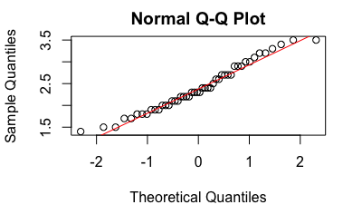

It shows that the data is normal, to verify that we do the the Shapiro Wilk test.

```r
shapiro.test(lh)
```

```
    Shapiro-Wilk normality test

data:  lh
W = 0.97077, p-value = 0.2714
```

**Q3** The dataset “ChickWeight” contains the weight of chickens on four different diets, measured every 2 days from birth until 21 days of age. Analyse this data set using basic statistics, and answer the following questions:

- What is the average final weight (on the 21st day) for the chicks on each diet? Which diet causes the chicks to have the highest weight? The lowest weight?
- Calculate the 90%-confidence interval for the diets on the last day. Does this information changes your answer to the previous question?
- Repeat the two calculations above for the weight of the chicks after two days of life (Time = 2). What differences do you observe?

[figure not shown]

Avarage on the final day: 218.6888889

```r
average <-tapply(ChickWeight$weight, ChickWeight$Time, mean)
last.day <- ChickWeight[ChickWeight$Time==2, ]
qqnorm(last.day$weight)
shapiro.test(last.day$weight)
boxplot(last.day$weight ~ last.day$Diet)
summary(aov(last.day$weight~last.day$Diet))
plot(TukeyHSD(aov(last.day$weight~last.day$Diet)))
```

**Q4** Let’s evaluate the Central Limit Theorem under theoretical Distributions:

- The function *rexp* creates numbers following the exponential distribution with parameter lambda.
- Create a list “l1” containing 1000 observations from the exponential distribution, with lambda = 0.2
- Create a list “l2” containing 50 observations, which are the means of random groups of 20 observations from l1
- Compare the mean and the standard deviation of l1 and l2
- Test whether l1 and l2 follow a normal distribution
- Repeat the exercise above using a different theoretical distribution (see “R for Beginners”, page 13)

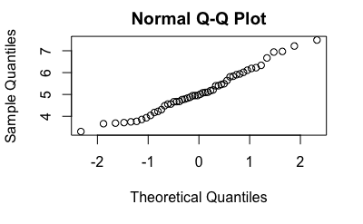

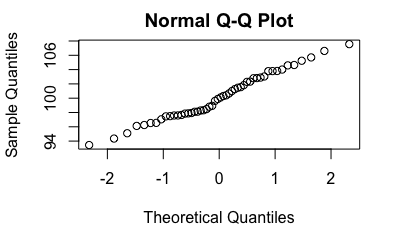

## Part 3: Statistical Inference

**Q1** The dataset “nhtemp” shows the mean annual temperature in New Haven, from 1912 to 1971. We want to answer the following question: Is the mean annual temperature in NH rising?

- First try to answer the question by plotting the dataset. What do you observe?
- There are many ways to formalize this question as a hypothesis. Suggest at least two different hypothesis tests that could be made with this data.
- Let’s perform the following inferential analysis: Is the mean difference between the temperature of consecutive years above zero?
- First calculate from the dataset, the list of differences in consecutive years.
- Next, we will try a one-sample test of this mean against the value 0:
  - Test if the differences follow a normal distribution
  - Estimate the mean and the variance of the sample
  - Calculate the z-statistic and perform the inference using the z-test.
  - Calculate the significance, power, and p-statistic of the test.

```r
# Hint: You can obtain the difference between consecutive years as follows:
consecutive.difference = diff(nhtemp) #hint! :-)
```

**Q2** The dataset “sleep” shows an experiment where a group of 10 patients tested two drugs for sleeping (1 and 2). Let’s compare the performance of drugs 1 and 2 using statistical inference.

- First, make a basic analysis of the two drugs: Calculate the mean, standard deviation, and 90% confidence interval for both samples. Plot the confidence intervals.
- Perform a two-sample t-test, and a paired t-test to compare the results of the two drugs
- Verify the assumptions of the tests for this data
- Describe the results and conclusions of the test, making sure to mention the power and confidence of the results obtained.